# EPI 590R Final Project

Author

Kelly Longhini

## Description of the Data

The data is from a retrospective cohort study of cardiac catherterization and outcomes, from the Duke University Cardiovascular Disease Databank. This data set contains 3504 participants with chest pain who were evaluated with cardiac catheterization. The findings of the catheterization are summarized in two outcome variables, sigdz (at least 75% blockage of at least one of the major coronary arteries) and tvdlm (blockage of either all three of the coronary vessels, or blockage of the left main coronary artery). Risk factors, including sex, age, duration of symptoms (cad_dur), and the serum cholesterol level (choleste) are included.

Source: https://htmlpreview.github.io/?https://github.com/higgi13425/medicaldata/blob/master/man/description_docs/cath_desc.html

```r
# Load in the catheterization R data set using the here package
load(here::here("data", "raw", "cath.rda"))

cath <- cath %>%
  mutate(sex_cat = factor(cath$sex, labels = c("Male", "Female")),
         sigdz_cat = factor(cath$sigdz, labels = c("No", "Yes")),
         tvdlm_cat = factor(cath$tvdlm, labels = c("No", "Yes"))
  )
```

## Descriptive Statistics

Table 1: Table of descriptive statistics

| **Characteristic** | **Male** N = 2,405 <sup>1</sup> | **Female** N = 1,099 <sup>1</sup> | **Overall** N = 3,504 <sup>1</sup> |
| --- | --- | --- | --- |
| Age (years) | 52 (45, 58) | 54 (47, 61) | 52 (46, 59) |
| Duration of chest pain symptoms (days) | 17 (4, 60) | 20 (6, 56) | 18 (4, 60) |
| Serum cholesterol level (mg/dL) | 223 (195, 255) | 230 (199, 265) | 225 (196, 259) |
| Missing | 836 | 410 | 1,246 |
| Significant coronary disease (at least 75% blockage of at least one of the major coronary arteries) | 1,872 (78%) | 462 (42%) | 2,334 (67%) |
| Three vessel disease/left main disease (blockage of either all three of the coronary vessels, or blockage of the left main coronary artery) | 941 (39%) | 188 (17%) | 1,129 (32%) |
| Missing | 1 | 2 | 3 |

<sup>1</sup> Median (Q1, Q3); n (%)

Table 1 displays descriptive statistics for the predictor and outcome variables in the data set, including age, duration of chest pain symptoms, serum cholesterol level, and coronary artery and coronary vessel blockages.

The overall median duration of chest pain symptoms is 18 days.

```r
cholesterol_median_male <- inline_text(table1, variable = "choleste",
                         column = "stat_1")
cholesterol_median_female <- inline_text(table1, variable = "choleste",
                         column = "stat_2")
```

The median serum cholesterol level for males (223 (195, 255) mg/dL) is lower than the median serum cholesterol level for females (230 (199, 265) mg/dL) in the study.

## Logistic Regression

```r
logistic_model <- glm(sigdz ~ age + sex_cat + cad_dur + choleste,
                                            data = cath, family = binomial())
```

Table 2: Logistic regression results

| **Characteristic** | **OR** <sup>1</sup> | **95% CI** <sup>1</sup> | **p-value** |
| --- | --- | --- | --- |
| Age (years) | 1.08 | 1.06, 1.09 | <0.001 |
| Sex |  |  |  |
| Male | — | — |  |
| Female | 0.12 | 0.10, 0.15 | <0.001 |
| Duration of chest pain (days) | 1.00 | 1.00, 1.00 | 0.094 |
| Serum cholesterol level (mg/dL) | 1.01 | 1.01, 1.01 | <0.001 |

<sup>1</sup> OR = Odds Ratio, CI = Confidence Interval

Table 2 shows the regression of significant coronary disease on a series of predictor variables, including age, sex, duration of chest pain, and serum cholesterol level.

# Histogram of Cholesterol

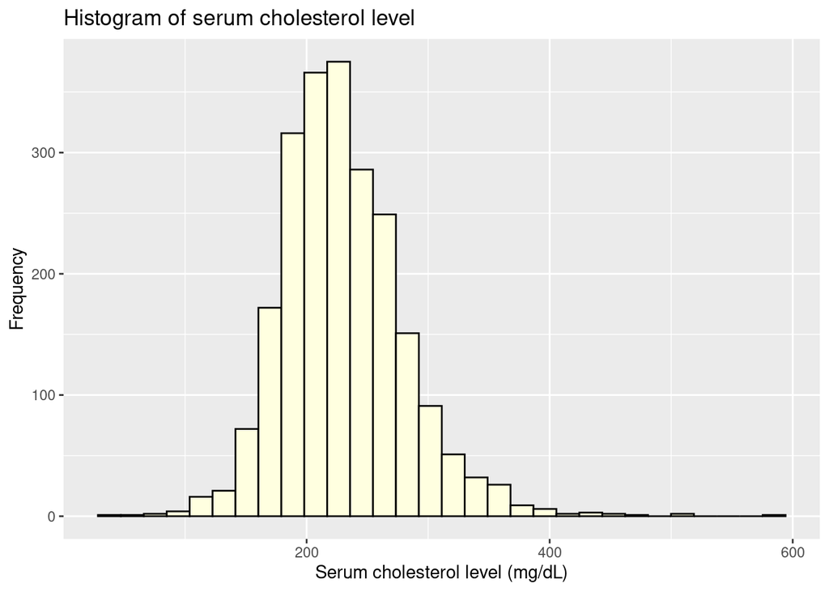

Figure 1: Histogram of serum cholesterol level

Figure 1 depicts a histogram of serum cholesterol levels (mg/dL) for all participants in the study.

```r
# Save the figure
ggsave(plot = hist,
       filename = here::here("figures", "histogram.pdf"))
```

# Standard Deviation Function

```r
# Create the standard deviation function
new_sd <- function(x) {
    n <- length(x)
    mean_val <- sum(x)/n
    variance <- sum((x - mean_val)^2) / (n - 1)
    sd_val <- (variance)^0.5
    return(sd_val)
}

# Test the standard deviation function
new_sd(x = c(2, 5, 34, 23, 3))
```

```
[1] 14.36315
```

```r
sd(x = c(2, 5, 34, 23, 3))
```

```
[1] 14.36315
```

```r
# Use the standard deviation function with the data
new_sd(x = cath$cad_dur)
```

```
[1] 58.15655
```

```r
sd(cath$cad_dur)
```

```
[1] 58.15655
```

```r
cad_dur_sd <- new_sd(x = cath$cad_dur)

new_sd(x = cath$age)
```

```
[1] 9.93208
```

```r
sd(cath$age)
```

```
[1] 9.93208
```

```r
age_sd <- new_sd(x = cath$age)
```

The standard deviation of the duration of chest pain symptoms is 58.1565509 days.

The standard deviation of age in the sample is 9.9320801 years.